# Social support effects on subjective effort and fatigue, energy expenditure, and outputs during physical exercise: Study 3 power analyses

### Arran J Davis

##### Institute of Human Sciences, University of Oxford

##### arran.davis@anthro.ox.ac.uk | davis.arran@gmail.com

##### 8 April 2024

## Introduction

This study will employ a within subjects design to manipulate participants’ perceptions of social support during a rowing trial. The rowing trial will consist of two segments. In Segment 1, participants will row at a fixed pace (established during a preliminary incremental ramp test) for 20 minutes. They will then rest for five minutes before completing a maximum effort 2 km time trial.

The main predictor variable is the experimental condition (`condition`). Participants will be exposed to three experimental conditions; (1) a condition in which they see a photo of a support figure (a friend, family member, or partner) while rowing, (2) a condition in which they see a photo of a support figure while rowing *and* they warm-up with a teammate, and (3) a control condition where they see a photo of a stranger (matched to the support figure by age, gender, and ethnicity). The design will be counterbalanced and the order in which participants complete each experimental condition (`session_number`) will be randomised. Before they complete the experimental conditions, participants will complete the rowing trial two separate times as a means of assessing how reliably they can perform the 2 km time trial (Segment 2); only those participants who can reliably perform the 2 km time trial will do the experimental conditions.

## Hypotheses, data simulations, and power analyses

### Social support effects on 2 km rowing times

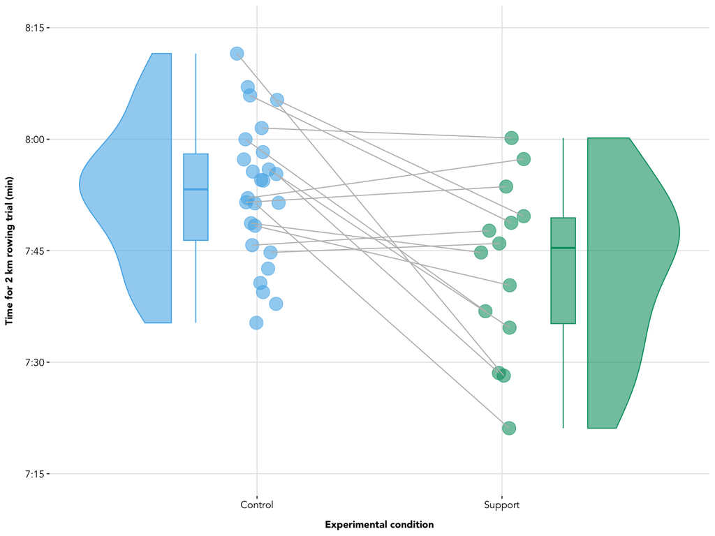

#### Data simulations for power analysis

Power analyses were carried out using the `faux` package in R (DeBruine, 2021). Using the dataset described above as a reference, 36,000 simulated sample datasets were created. This was done through sampling different simulated experimental results for the 2 km time variable (`time_2km`) that varied according to sample size (15, 20, 25, 30, 35, 40) and the effect of `condition` (1.25%, 2.5%, 3.75%, 5%, 6.25%, and 7.5% faster times in the social support condition, as compared to the control condition). Regarding the fixed effect of `session_number`, all simulations assumed 0.5% faster scores for the experimental conditions following the first (i.e., practice / conditioning effects). For all simulations, the intercept was set to 8 min, the random intercept standard deviation was set 0.5, and random slope standard deviations of 0.25 and 0.1 were set for `condition` and `session_number`, respectively. The correlation between random effects was set to 0 and the error term SD was set to 0.1.

For each of the 36,000 simulated datasets, the statistical significance of the `condition` predictor variable on `time_2km` was assessed using the following hierarchical linear regression model.

```
lmer(time_2km ~ condition + session_number + (1 | participant), data = data)
```

Social support condition (`condition`) was the main fixed effect of interest, and the order in which the experimental conditions were presented in relation to the control condition (`session_number`) was included as a fixed effect covariate. Participant (`participant`) was the level-two random effect. The model was fit using the `lme4` package (Bates et al., 2014). Data simulation indicated that model convergence was not possible with more complex random effects structures (e.g., random slopes for `condition`).

The power analyses reported below were calculated as the frequency of the 1,000 *p*-values (in each combination of effect size and sample size) that were less than 0.05 for the `condition` *b*-coefficient that compared participants’ 2 km times in the social support and control conditions.

#### Power analysis results

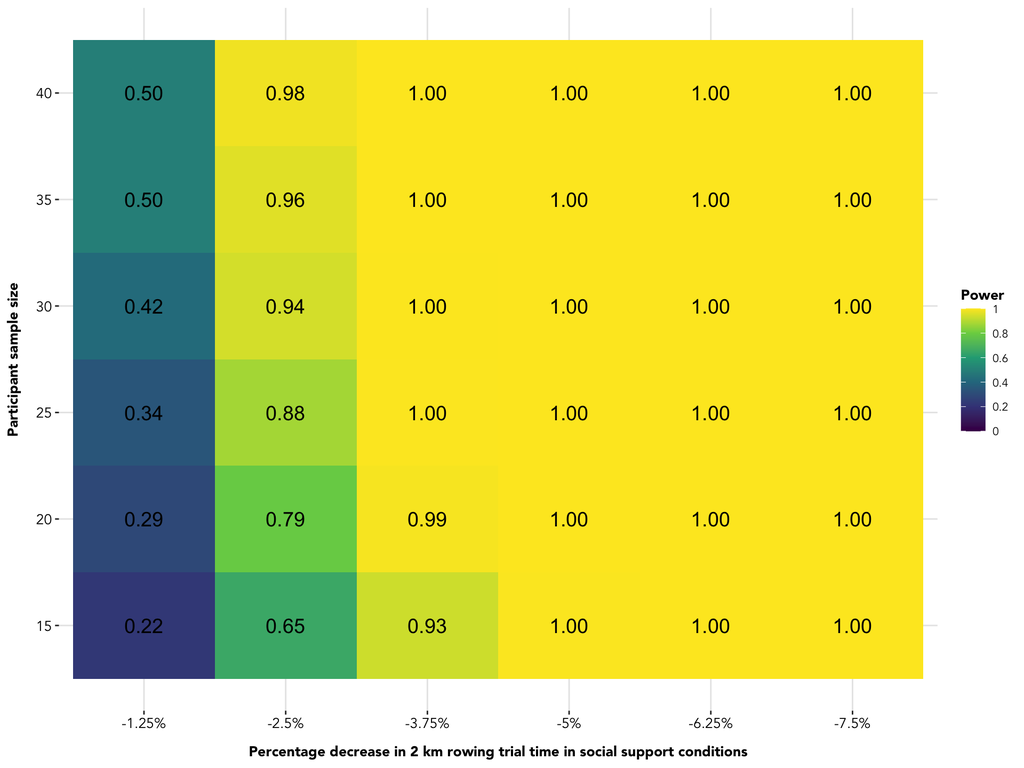

### Interaction between social support and time on perceptions of effort and fatigue

This power analysis is for hypotheses related to *both* perceptions of effort and perceptions of fatigue; since the variables are measured in the same way, and our hypotheses are the same for each variable, we will only carry out calculations for perceptions of fatigue, as it is measured less often (thereby decreasing the power of hypothesis tests on perceived fatigue, as compared to perceived effort). As with the condition-wise effects on 2 km rowing times, we only conduct a power analysis to compare the social support condition in which participants see a photo of a support figure while rowing with the control condition, as this social support condition is hypothesised to have an equivalent or smaller effect than the social support condition involving seeing the photo of a support figure while rowing *and* warming-up with a teammate.

Study 1 of this project showed similar interactions between experimental conditions and time (measurement number) on participants’ perceptions of effort (*b* = -0.04) and fatigue (*b* = -0.07). Perceptions of effort and fatigue increased over time in both conditions, but this increase was steeper in the control condition. A simulation of this data for perceived fatigue is plotted below for the 24 measures of perceived fatigue that will be measured over the 20-minute steady state rowing trial that makes up Segment 1 of the Exercise Task.

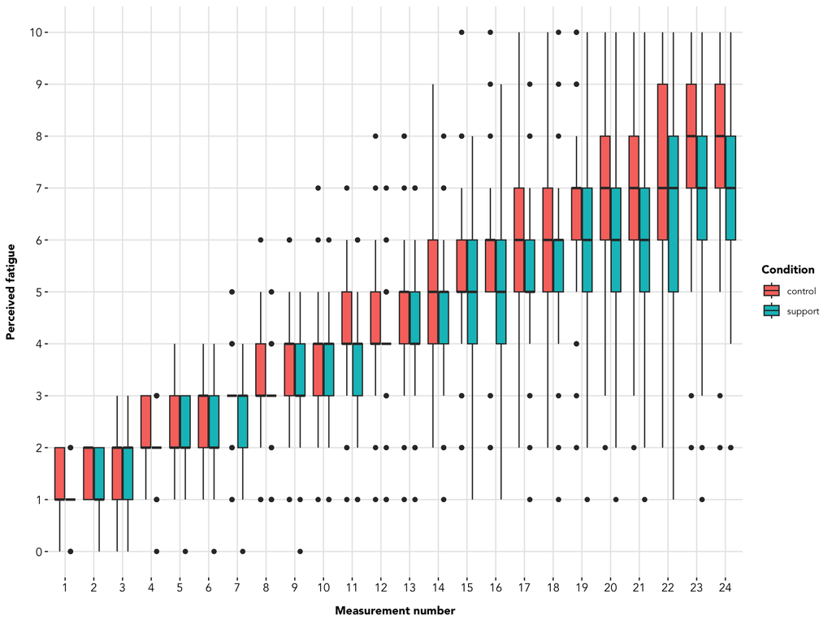

#### Data simulations for power analysis

```
lmer(fatigue ~ condition * measurement_number + session_number + (1 | participant), data = data)
```

The `condition` by `measurement_number` interaction effect was the main effect of interest, and the order in which the experimental conditions were presented (`session_number`) was included as a fixed effect covariate. Participant (`participant`) was the level-two random effect. The model was fit using the `lme4` package. Data simulation indicated that model convergence was not possible with more complex random effects structures (e.g., random slopes for `condition`).

#### Power analysis results

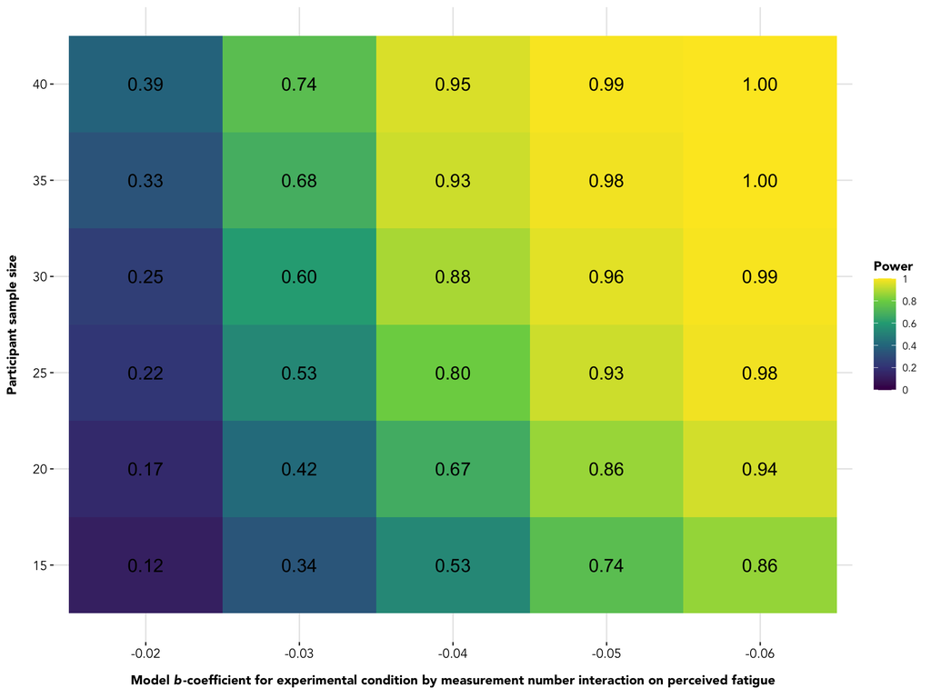

Results suggest that at least 25 participants are needed to have sufficient power (0.80) to detect a `condition` by `measurement_number` interaction on perceived fatigue (`fatigue`) that has a *b*-coefficient -0.04 (the smallest effect observed for the `condition` by `measurement_number` interactions on perceived effort and perceived fatigue in Study 1).

### Citations

Bates, D., Maechler, M., Bolker, B., & Walker, S. (2014). lme4: Linear mixed-effects models using Eigen and S4. *R package version*, *1*(7), 1-23.

DeBruine L (2021). *faux: Simulation for Factorial Designs*. doi: 10.5281/zenodo.2669586, R package version 1.1.0, https://debruine.github.io/faux/.